# Kmeans, Kmedoid Clustering 資料分群

#### Gap

Gap Statistic法可以應用在任何分群演算法上（比如說分裂式分群或階層式分群）。 Gap Statistic(k): 比較不同k水準值下，實際觀測值分群結果的群內總變異($Wk$)與自助抽樣法B回產生樣本分群結果期望群內總變異($\bar{W_k}$)，即衡量觀測和預期之間的差距。
群內總變異的期望值($\bar{W_k}$): 使用Bootstap進行重新抽樣，計算k水準值下重新抽樣樣本分群結果的群內總變異(Wki∼WkB)，並計算 k水準值下的群內總變異期望值，即
$$E(W_k)=mean(W_k)=\bar{W_k}= \frac{1}{B}∑_{i=1}^{B}log(W_{ki})$$

群內總變異的標準差$Standard Deviation(Sd(W_k))$:
$$Sd(Wk)=\sqrt{\frac{1}{B}∑_i^B=(log(W_{ki})–Wk)^2}$$
群內總變異樣本平均值的標準誤Standard Error(sk): 即樣本平均值($\bar{W_k}$)與真實母體平均值(μk)的變異。
$$s_k=sd(k)×\sqrt{1+\frac{1}{B}}$$
自助抽樣將模擬蒙地卡羅的採樣過程，也就是說每一個變數$x_i$，會依據他們的最大最小值範圍$[min(x_i),max(x_i)]$，來重新計算標準化後的值。 Gap Statistic則是計算在不同k水準值下，觀測與預期值的總群內變異差異，公式如下：
$$Gap(k)=\bar{W_k}−W_k=\frac1B∑_i^Blog(W_{ki})–W_k$$
並且我們選擇使Gap(k)最大化的最小的k值，以符合：
$$Gap(k)≥Gap(k+1)−s_{k+1}$$

**即表示k群的分群結構和虛無假設的uniform分配（沒有分群）有很大的差距。**  
我們可以透過cluster套件中的clusGap()函數來計算不同k水平值對應的該統計量(Gap)以及標準誤(Standard Error, SE)。也因為我們要找到使最大化Gap(k)的最小k值，所以記得調整參數method=”firstmax”。將結果印出後，我們可看到每個對應k水平值的：  
* logW: 觀測值群內總變異。 * E.logW: 群內總變異期望值。 * gap: E.logW – logW統計量。 * SE.sim: 標準誤(simulation standard error)。

```r
# compute gap statistic
set.seed(123)
gap_stat <- clusGap(x = inputData, FUN = kmeans, nstart = 25,
                    K.max = 10, B = 50)
# Print the result
print(gap_stat, method = "firstmax")
```

```
## Clustering Gap statistic ["clusGap"] from call:
## clusGap(x = inputData, FUNcluster = kmeans, K.max = 10, B = 50,     nstart = 25)
## B=50 simulated reference sets, k = 1..10; spaceH0="scaledPCA"
##  --> Number of clusters (method 'firstmax'): 4
##           logW   E.logW       gap     SE.sim
##  [1,] 3.458369 3.640154 0.1817845 0.04422857
##  [2,] 3.135112 3.372283 0.2371717 0.03559601
##  [3,] 2.977727 3.233771 0.2560446 0.03749193
##  [4,] 2.826221 3.119172 0.2929511 0.04067348
##  [5,] 2.738868 3.019965 0.2810969 0.04185469
##  [6,] 2.666967 2.930002 0.2630347 0.04105040
##  [7,] 2.609895 2.852152 0.2422572 0.04184725
##  [8,] 2.539156 2.778562 0.2394054 0.04292750
##  [9,] 2.468162 2.711752 0.2435901 0.04344197
## [10,] 2.407265 2.647595 0.2403307 0.04548446
```

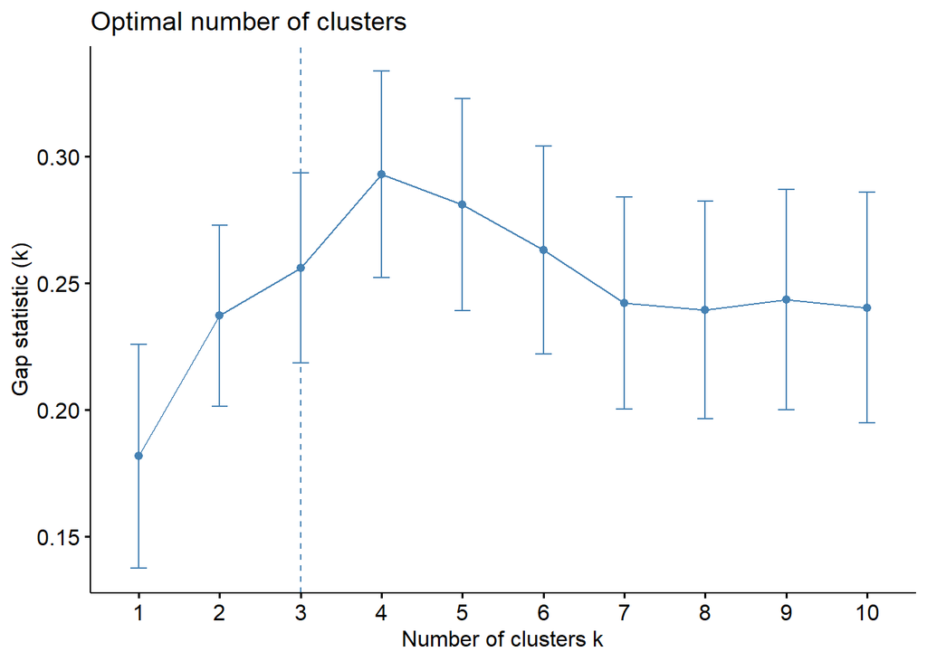

```r
fviz_gap_stat(gap_stat)
```